# Starbucks Capstone Challenge

### Introduction

This data set contains simulated data that mimics customer behavior on the Starbucks rewards mobile app. Once every few days, Starbucks sends out an offer to users of the mobile app. An offer can be merely an advertisement for a drink or an actual offer such as a discount or BOGO (buy one get one free). Some users might not receive any offer during certain weeks.

Not all users receive the same offer, and that is the challenge to solve with this data set.

Your task is to combine transaction, demographic and offer data to determine which demographic groups respond best to which offer type. This data set is a simplified version of the real Starbucks app because the underlying simulator only has one product whereas Starbucks actually sells dozens of products.

Every offer has a validity period before the offer expires. As an example, a BOGO offer might be valid for only 5 days. You'll see in the data set that informational offers have a validity period even though these ads are merely providing information about a product; for example, if an informational offer has 7 days of validity, you can assume the customer is feeling the influence of the offer for 7 days after receiving the advertisement.

You'll be given transactional data showing user purchases made on the app including the timestamp of purchase and the amount of money spent on a purchase. This transactional data also has a record for each offer that a user receives as well as a record for when a user actually views the offer. There are also records for when a user completes an offer.

Keep in mind as well that someone using the app might make a purchase through the app without having received an offer or seen an offer.

### Example

To give an example, a user could receive a discount offer buy 10 dollars get 2 off on Monday. The offer is valid for 10 days from receipt. If the customer accumulates at least 10 dollars in purchases during the validity period, the customer completes the offer.

However, there are a few things to watch out for in this data set. Customers do not opt into the offers that they receive; in other words, a user can receive an offer, never actually view the offer, and still complete the offer. For example, a user might receive the "buy 10 dollars get 2 dollars off offer", but the user never opens the offer during the 10 day validity period. The customer spends 15 dollars during those ten days. There will be an offer completion record in the data set; however, the customer was not influenced by the offer because the customer never viewed the offer.

### Cleaning

This makes data cleaning especially important and tricky.

You'll also want to take into account that some demographic groups will make purchases even if they don't receive an offer. From a business perspective, if a customer is going to make a 10 dollar purchase without an offer anyway, you wouldn't want to send a buy 10 dollars get 2 dollars off offer. You'll want to try to assess what a certain demographic group will buy when not receiving any offers.

### Final Advice

Because this is a capstone project, you are free to analyze the data any way you see fit. For example, you could build a machine learning model that predicts how much someone will spend based on demographics and offer type. Or you could build a model that predicts whether or not someone will respond to an offer. Or, you don't need to build a machine learning model at all. You could develop a set of heuristics that determine what offer you should send to each customer (i.e., 75 percent of women customers who were 35 years old responded to offer A vs 40 percent from the same demographic to offer B, so send offer A).

# Data Sets

The data is contained in three files:

- portfolio.json - containing offer ids and meta data about each offer (duration, type, etc.)
- profile.json - demographic data for each customer
- transcript.json - records for transactions, offers received, offers viewed, and offers completed

Here is the schema and explanation of each variable in the files:

**portfolio.json**

- id (string) - offer id
- offer_type (string) - type of offer ie BOGO, discount, informational
- difficulty (int) - minimum required spend to complete an offer
- reward (int) - reward given for completing an offer
- duration (int) - time for offer to be open, in days
- channels (list of strings)

**profile.json**

- age (int) - age of the customer
- became_member_on (int) - date when customer created an app account
- gender (str) - gender of the customer (note some entries contain 'O' for other rather than M or F)
- id (str) - customer id
- income (float) - customer's income

**transcript.json**

- event (str) - record description (ie transaction, offer received, offer viewed, etc.)
- person (str) - customer id
- time (int) - time in hours since start of test. The data begins at time t=0
- value - (dict of strings) - either an offer id or transaction amount depending on the record

**Note:** If you are using the workspace, you will need to go to the terminal and run the command `conda update pandas` before reading in the files. This is because the version of pandas in the workspace cannot read in the transcript.json file correctly, but the newest version of pandas can. You can access the termnal from the orange icon in the top left of this notebook.

You can see how to access the terminal and how the install works using the two images below. First you need to access the terminal:

[figure not shown]

Then you will want to run the above command:

[figure not shown]

Finally, when you enter back into the notebook (use the jupyter icon again), you should be able to run the below cell without any errors.

```python
import pandas as pd
import numpy as np
import math
import json
import matplotlib.pyplot as plt
%matplotlib inline

# read in the json files
portfolio = pd.read_json('data/portfolio.json', orient='records', lines=True)
profile = pd.read_json('data/profile.json', orient='records', lines=True)
transcript = pd.read_json('data/transcript.json', orient='records', lines=True)
```

### Understanding data

- portfolio DataFrame is holding → Offer Details

```python
print(portfolio.shape)
portfolio.head()
```

```
(10, 6)
```

|  | reward | channels | difficulty | duration | offer_type | id |
| --- | --- | --- | --- | --- | --- | --- |
| 0 | 10 | [email, mobile, social] | 10 | 7 | bogo | ae264e3637204a6fb9bb56bc8210ddfd |
| 1 | 10 | [web, email, mobile, social] | 10 | 5 | bogo | 4d5c57ea9a6940dd891ad53e9dbe8da0 |
| 2 | 0 | [web, email, mobile] | 0 | 4 | informational | 3f207df678b143eea3cee63160fa8bed |
| 3 | 5 | [web, email, mobile] | 5 | 7 | bogo | 9b98b8c7a33c4b65b9aebfe6a799e6d9 |
| 4 | 5 | [web, email] | 20 | 10 | discount | 0b1e1539f2cc45b7b9fa7c272da2e1d7 |

```python
backup_transcript=transcript
```

`Below are the important columns for portfolio`

- offer_type: Need to check which kind of offer types it contain
- channels: Where can the offer be sent
- duration: How long the offer is valid in days
- reward and difficulty: Conditions to complete the offer

```python
print(profile.shape)
profile.head(1)
```

```
(17000, 5)
```

|  | gender | age | id | became_member_on | income |
| --- | --- | --- | --- | --- | --- |
| 0 | None | 118 | 68be06ca386d4c31939f3a4f0e3dd783 | 20170212 | NaN |

`Below are the important columns for profile`

- age: Users with age=118 look to be suspicious and it also has NaN values need to check in detail
- income: Importatn factor, need to handle if NaN
- became_member_on: Needs to be converted to a proper date
- id: User ID will be the index to merge with transcript dataset

```python
transcript.head()
```

|  | person | event | value | time |
| --- | --- | --- | --- | --- |
| 0 | 78afa995795e4d85b5d9ceeca43f5fef | offer received | {'offer id': '9b98b8c7a33c4b65b9aebfe6a799e6d9'} | 0 |
| 1 | a03223e636434f42ac4c3df47e8bac43 | offer received | {'offer id': '0b1e1539f2cc45b7b9fa7c272da2e1d7'} | 0 |
| 2 | e2127556f4f64592b11af22de27a7932 | offer received | {'offer id': '2906b810c7d4411798c6938adc9daaa5'} | 0 |
| 3 | 8ec6ce2a7e7949b1bf142def7d0e0586 | offer received | {'offer id': 'fafdcd668e3743c1bb461111dcafc2a4'} | 0 |
| 4 | 68617ca6246f4fbc85e91a2a49552598 | offer received | {'offer id': '4d5c57ea9a6940dd891ad53e9dbe8da0'} | 0 |

`Below will be the important columns for transcript`

- event: activities like Offer received, will have to create dummies
- value: Offer ID / transaction amount (needs to be extracted)
- time: Recorded in hours from the start of the experiment

### Data Cleaning & Preprocessing

- portfolio

```python
print(portfolio.shape)
#offer types we found are 3 'bogo', 'informational', 'discount'
print(portfolio['offer_type'].unique())
```

```
(10, 6)
['bogo' 'informational' 'discount']
```

```python
#we could see from the head itself that channels column has list in it
#we might have to explode it, but for now, let's break the
#offer_type column list values into separate columns using get dummies
print(type(portfolio['channels'][0]))
portfolio = pd.get_dummies(portfolio, columns=['offer_type'])
```

```
<class 'list'>
```

```python
#the output of get_dummies is a boolean 1, it's always better to convert in
#the form of 1,0
portfolio['offer_type_bogo']= portfolio['offer_type_bogo'].astype(int)
```

```python
portfolio['offer_type_discount']= portfolio['offer_type_discount'].astype(int)
portfolio['offer_type_informational']= portfolio['offer_type_informational'].astype(int)
```

```python
portfolio.head()
```

|  | reward | channels | difficulty | duration | id | offer_type_bogo | offer_type_discount | offer_type_informational |
| --- | --- | --- | --- | --- | --- | --- | --- | --- |
| 0 | 10 | [email, mobile, social] | 10 | 7 | ae264e3637204a6fb9bb56bc8210ddfd | 1 | 0 | 0 |
| 1 | 10 | [web, email, mobile, social] | 10 | 5 | 4d5c57ea9a6940dd891ad53e9dbe8da0 | 1 | 0 | 0 |
| 2 | 0 | [web, email, mobile] | 0 | 4 | 3f207df678b143eea3cee63160fa8bed | 0 | 0 | 1 |
| 3 | 5 | [web, email, mobile] | 5 | 7 | 9b98b8c7a33c4b65b9aebfe6a799e6d9 | 1 | 0 | 0 |
| 4 | 5 | [web, email] | 20 | 10 | 0b1e1539f2cc45b7b9fa7c272da2e1d7 | 0 | 1 | 0 |

`Portfolio somewhat looks okay for now, let's check for Profile now`

- profile - DATA CLEANING

```python
#we must convert the date in proper format

profile['became_member_on'] = pd.to_datetime(profile['became_member_on'], format="%Y%m%d")

#having membership_days can also play a good role at later stage for our
#model to make predictions
profile['membership_days'] = (profile['became_member_on'] - profile['became_member_on'].min()).dt.days

#skipped dropping of column
#profile.drop(columns=['became_member_on'], inplace=True)


print(profile['gender'].isna().sum())
# profile['income'].fillna(profile['income'].median(), inplace=True)
# profile.loc[profile['age'] == 118, 'age'] = np.nan
# profile['age'].fillna(profile['age'].median(), inplace=True)
print(profile.shape)
print(profile['gender'].unique())
profile.head()
```

```
2175
(17000, 6)
[None 'F' 'M' 'O']
```

|  | gender | age | id | became_member_on | income | membership_days |
| --- | --- | --- | --- | --- | --- | --- |
| 0 | None | 118 | 68be06ca386d4c31939f3a4f0e3dd783 | 2017-02-12 | NaN | 1294 |
| 1 | F | 55 | 0610b486422d4921ae7d2bf64640c50b | 2017-07-15 | 112000.0 | 1447 |
| 2 | None | 118 | 38fe809add3b4fcf9315a9694bb96ff5 | 2018-07-12 | NaN | 1809 |
| 3 | F | 75 | 78afa995795e4d85b5d9ceeca43f5fef | 2017-05-09 | 100000.0 | 1380 |
| 4 | None | 118 | a03223e636434f42ac4c3df47e8bac43 | 2017-08-04 | NaN | 1467 |

```python
#after analyzing the data, understood that all records with age 118 are dummy
# and will serve no purpose in helping us to make a better analysis
profile.drop(profile[(profile['age'] == 118) & (profile['income'].isna())].index, inplace=True)
```

```python
profile.head()
```

|  | gender | age | id | became_member_on | income | membership_days |
| --- | --- | --- | --- | --- | --- | --- |
| 1 | F | 55 | 0610b486422d4921ae7d2bf64640c50b | 2017-07-15 | 112000.0 | 1447 |
| 3 | F | 75 | 78afa995795e4d85b5d9ceeca43f5fef | 2017-05-09 | 100000.0 | 1380 |
| 5 | M | 68 | e2127556f4f64592b11af22de27a7932 | 2018-04-26 | 70000.0 | 1732 |
| 8 | M | 65 | 389bc3fa690240e798340f5a15918d5c | 2018-02-09 | 53000.0 | 1656 |
| 12 | M | 58 | 2eeac8d8feae4a8cad5a6af0499a211d | 2017-11-11 | 51000.0 | 1566 |

```python
print(profile['gender'].isna().sum())
```

```
0
```

```python
#now we know that income is important so need to check if any income
#is NaN if yes we need to fill them with right approach
profile[profile['income'].isna()]

#we are good here
```

|  | gender | age | id | became_member_on | income | membership_days |
| --- | --- | --- | --- | --- | --- | --- |

- Transcript - DATA CLEANING

`we understood from the preface that transcript can carry either the offer_id or the transaction amount we need to use apply to parse the value column to extract offer and amount respectively`

```python
#the format of value is key: value pair, so we can utilize the dictionary
#methods to extract relevant values from it

transcript['offer_id']= transcript['value'].apply(lambda x : x.get('offer id',x.get('offer_id', np.nan)))
transcript.head()
```

|  | person | event | value | time | offer_id |
| --- | --- | --- | --- | --- | --- |
| 0 | 78afa995795e4d85b5d9ceeca43f5fef | offer received | {'offer id': '9b98b8c7a33c4b65b9aebfe6a799e6d9'} | 0 | 9b98b8c7a33c4b65b9aebfe6a799e6d9 |
| 1 | a03223e636434f42ac4c3df47e8bac43 | offer received | {'offer id': '0b1e1539f2cc45b7b9fa7c272da2e1d7'} | 0 | 0b1e1539f2cc45b7b9fa7c272da2e1d7 |
| 2 | e2127556f4f64592b11af22de27a7932 | offer received | {'offer id': '2906b810c7d4411798c6938adc9daaa5'} | 0 | 2906b810c7d4411798c6938adc9daaa5 |
| 3 | 8ec6ce2a7e7949b1bf142def7d0e0586 | offer received | {'offer id': 'fafdcd668e3743c1bb461111dcafc2a4'} | 0 | fafdcd668e3743c1bb461111dcafc2a4 |
| 4 | 68617ca6246f4fbc85e91a2a49552598 | offer received | {'offer id': '4d5c57ea9a6940dd891ad53e9dbe8da0'} | 0 | 4d5c57ea9a6940dd891ad53e9dbe8da0 |

```python
#similar wya to get the amount
transcript['amount']= transcript['value'].apply(lambda x : x.get('amount',0))
transcript.head()
```

|  | person | event | value | time | offer_id | amount |
| --- | --- | --- | --- | --- | --- | --- |
| 0 | 78afa995795e4d85b5d9ceeca43f5fef | offer received | {'offer id': '9b98b8c7a33c4b65b9aebfe6a799e6d9'} | 0 | 9b98b8c7a33c4b65b9aebfe6a799e6d9 | 0.0 |
| 1 | a03223e636434f42ac4c3df47e8bac43 | offer received | {'offer id': '0b1e1539f2cc45b7b9fa7c272da2e1d7'} | 0 | 0b1e1539f2cc45b7b9fa7c272da2e1d7 | 0.0 |
| 2 | e2127556f4f64592b11af22de27a7932 | offer received | {'offer id': '2906b810c7d4411798c6938adc9daaa5'} | 0 | 2906b810c7d4411798c6938adc9daaa5 | 0.0 |
| 3 | 8ec6ce2a7e7949b1bf142def7d0e0586 | offer received | {'offer id': 'fafdcd668e3743c1bb461111dcafc2a4'} | 0 | fafdcd668e3743c1bb461111dcafc2a4 | 0.0 |
| 4 | 68617ca6246f4fbc85e91a2a49552598 | offer received | {'offer id': '4d5c57ea9a6940dd891ad53e9dbe8da0'} | 0 | 4d5c57ea9a6940dd891ad53e9dbe8da0 | 0.0 |

### VISUALIZE DATA

- let's try to visualize data based on each df to understand what infomration can we get
- Visualizing PROFILE DataFrame

```python
print(profile.describe())
```

```
                age               became_member_on         income  \
count  14825.000000                          14825   14825.000000
mean      54.393524  2017-02-18 12:30:15.419898880   65404.991568
min       18.000000            2013-07-29 00:00:00   30000.000000
25%       42.000000            2016-05-20 00:00:00   49000.000000
50%       55.000000            2017-08-02 00:00:00   64000.000000
75%       66.000000            2017-12-30 00:00:00   80000.000000
max      101.000000            2018-07-26 00:00:00  120000.000000
std       17.383705                            NaN   21598.299410

       membership_days
count     14825.000000
mean       1300.521012
min           0.000000
25%        1026.000000
50%        1465.000000
75%        1615.000000
max        1823.000000
std         419.205158
```

`Important points that we can see here`

```python
print(profile.isna().sum())
#no null values so we are good
```

```
gender              0
age                 0
id                  0
became_member_on    0
income              0
membership_days     0
dtype: int64
```

```python
profile.head()
```

|  | gender | age | id | became_member_on | income | membership_days |
| --- | --- | --- | --- | --- | --- | --- |
| 1 | F | 55 | 0610b486422d4921ae7d2bf64640c50b | 2017-07-15 | 112000.0 | 1447 |
| 3 | F | 75 | 78afa995795e4d85b5d9ceeca43f5fef | 2017-05-09 | 100000.0 | 1380 |
| 5 | M | 68 | e2127556f4f64592b11af22de27a7932 | 2018-04-26 | 70000.0 | 1732 |
| 8 | M | 65 | 389bc3fa690240e798340f5a15918d5c | 2018-02-09 | 53000.0 | 1656 |
| 12 | M | 58 | 2eeac8d8feae4a8cad5a6af0499a211d | 2017-11-11 | 51000.0 | 1566 |

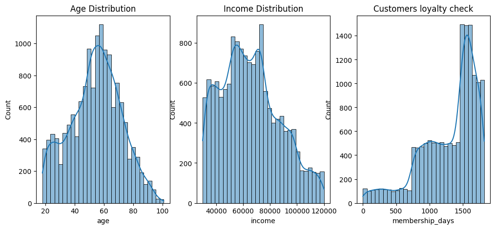

```python
#we will visualize te profile data based on what is the age and income disparity
#we can also check the age/income ration as well
import matplotlib.pyplot as plt
import seaborn as sns

plt.figure(figsize=(12,5))
plt.subplot(1,3,1)
sns.histplot(profile['age'], bins=30, kde=True)
plt.title('Age Distribution')

plt.subplot(1,3,2)
sns.histplot(profile['income'], bins=30, kde=True)
plt.title('Income Distribution')

plt.subplot(1,3,3)
sns.histplot(profile['membership_days'], bins=30, kde=True)
plt.title('Customers loyalty check')



plt.show()
```

## Wuu Huuu ~~

- Our histplot output justifies what we inferred from our describe() output.
- Age distribution follows a normal distribution, ranging from age 20 to 80
- While the income graph is a little right skewed, which confirms that majority of the population is earning berween 50-80k
- Membership days, show that we have a little left skewed graph, meaning we have new members joining at regular intervals.

```python
profile['gender'].unique()
```

```
array(['F', 'M', 'O'], dtype=object)
```

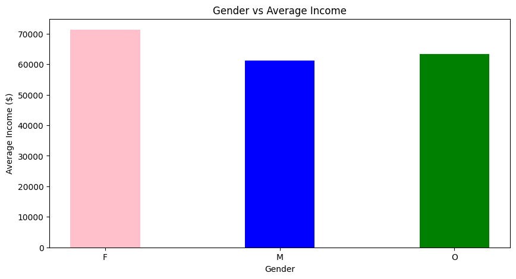

```python
import matplotlib.pyplot as plt

gender_income = profile.set_index('gender').groupby('gender')['income'].mean()
#print(gender_income)
gender_counts = profile['gender'].value_counts().sort_index()
#print(gender_counts)
colors = ['Pink', 'Blue', 'Green', 'Gray']


plt.figure(figsize=(10,5))
plt.bar(x=gender_counts.index, height=gender_income, width=0.4, color=colors[:len(gender_counts)])
plt.xlabel("Gender")
plt.ylabel("Average Income ($)")
plt.title("Gender vs Average Income")
plt.show()
```

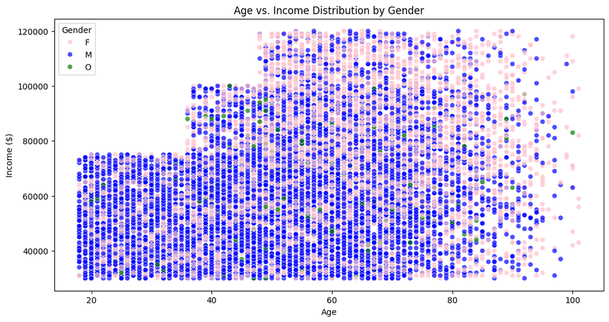

```python
import matplotlib.pyplot as plt
import seaborn as sns

plt.figure(figsize=(12,6))
sns.scatterplot(data=profile, x='age', y='income', hue='gender', palette={'M': 'blue', 'F': 'pink', 'O': 'green'}, alpha=0.7)
plt.xlabel("Age")
plt.ylabel("Income ($)")
plt.title("Age vs. Income Distribution by Gender")
plt.legend(title="Gender")
plt.show()
```

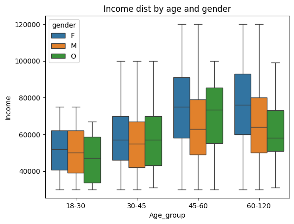

```python
bins=[18,30,45,60,120]
labels=["18-30", "30-45", "45-60","60-120"]
profile["age_group"]=pd.cut(profile['age'], bins=bins, labels=labels)
#profile.head()
sns.boxplot(data=profile, x='age_group', y='income', hue='gender')
plt.xlabel('Age_group')
plt.ylabel('Income')
plt.title('Income dist by age and gender')
plt.show()
```

`CONCLUSIVE ANSWER BASED ON SCATTER PLOT, BOXPLOT AND BAR GRAPH`

- Income values appear to be spread across different ages, with most data points concentrated between 50k to 80k.
- There is a strong linear trend of Female & Male gender in their gender group between age and income, income does increase with increase in age. But overall, in terms of avergae income, women are shining like a diamond, more power to them.
- While younger individuals (~20s) seem to have lower incomes, mid-life (30–70) has a wide variation in incomes.

### trying to visualize PORTFOLIO dataFrame

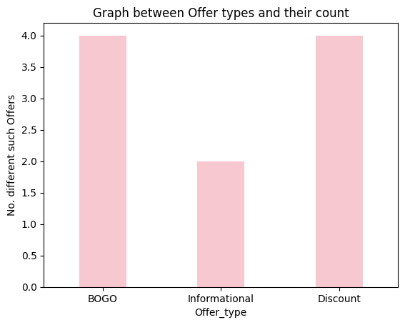

```python
# portfolio.head()
# offer_type={
#     'BOGO': portfolio['offer_type_bogo'].count()
# }
offer_type={
    'BOGO': portfolio[portfolio['offer_type_bogo'] == 1]['offer_type_bogo'].count(),
    'Informational': portfolio[portfolio['offer_type_informational'] == 1]['offer_type_informational'].count(),
    'Discount': portfolio[portfolio['offer_type_discount'] == 1]['offer_type_discount'].count()
}

offer_type_df=pd.DataFrame(list(offer_type.items()), columns=['Offer_type', 'count'])


sns.barplot(data=offer_type_df, x='Offer_type', y = 'count', color='Pink',
        width=0.4)
plt.xlabel('Offer_type')
plt.ylabel('No. different such Offers')
plt.title('Graph between Offer types and their count')
plt.show()
```

## why so much hustle for just plotting offer type?

- If we would utilized some other ways to parse offer_type column, we would have had offer_type column and it would have been a 1 line code to plot graph.
- But, learning how to create dictionary based on counts --> create a datafram --> and use that df to plot graph looked challeging.

```python
portfolio.head()
```

|  | reward | channels | difficulty | duration | id | offer_type_bogo | offer_type_discount | offer_type_informational |
| --- | --- | --- | --- | --- | --- | --- | --- | --- |
| 0 | 10 | [email, mobile, social] | 10 | 7 | ae264e3637204a6fb9bb56bc8210ddfd | 1 | 0 | 0 |
| 1 | 10 | [web, email, mobile, social] | 10 | 5 | 4d5c57ea9a6940dd891ad53e9dbe8da0 | 1 | 0 | 0 |
| 2 | 0 | [web, email, mobile] | 0 | 4 | 3f207df678b143eea3cee63160fa8bed | 0 | 0 | 1 |
| 3 | 5 | [web, email, mobile] | 5 | 7 | 9b98b8c7a33c4b65b9aebfe6a799e6d9 | 1 | 0 | 0 |
| 4 | 5 | [web, email] | 20 | 10 | 0b1e1539f2cc45b7b9fa7c272da2e1d7 | 0 | 1 | 0 |

- Nothing much here as this is just a reference df

### VISUALIZING TRANSCRIPT

```python
print(transcript['event'].value_counts())
```

```
event
transaction        138953
offer received      76277
offer viewed        57725
offer completed     33579
Name: count, dtype: int64
```

```python
transcript.head()
```

|  | person | event | value | time | offer_id | amount |
| --- | --- | --- | --- | --- | --- | --- |
| 0 | 78afa995795e4d85b5d9ceeca43f5fef | offer received | {'offer id': '9b98b8c7a33c4b65b9aebfe6a799e6d9'} | 0 | 9b98b8c7a33c4b65b9aebfe6a799e6d9 | 0.0 |
| 1 | a03223e636434f42ac4c3df47e8bac43 | offer received | {'offer id': '0b1e1539f2cc45b7b9fa7c272da2e1d7'} | 0 | 0b1e1539f2cc45b7b9fa7c272da2e1d7 | 0.0 |
| 2 | e2127556f4f64592b11af22de27a7932 | offer received | {'offer id': '2906b810c7d4411798c6938adc9daaa5'} | 0 | 2906b810c7d4411798c6938adc9daaa5 | 0.0 |
| 3 | 8ec6ce2a7e7949b1bf142def7d0e0586 | offer received | {'offer id': 'fafdcd668e3743c1bb461111dcafc2a4'} | 0 | fafdcd668e3743c1bb461111dcafc2a4 | 0.0 |
| 4 | 68617ca6246f4fbc85e91a2a49552598 | offer received | {'offer id': '4d5c57ea9a6940dd891ad53e9dbe8da0'} | 0 | 4d5c57ea9a6940dd891ad53e9dbe8da0 | 0.0 |

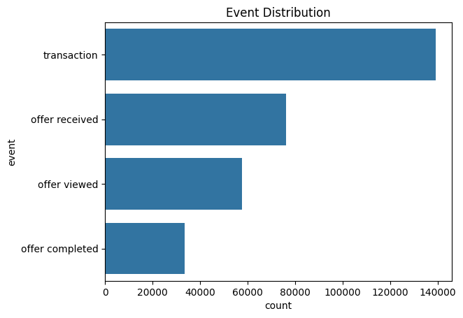

```python
#Nothing fancy, only visualizing the count values for each kind of events
sns.countplot(data=transcript, y='event', order=transcript['event'].value_counts().index)
plt.title('Event Distribution')
plt.show()
```

`INFERENCES`

- Ignoring transactions count for inferences, as it would always be greater than others, every single sell of a product accounts for a transaction event.
- Most frequent event: "offer received" (not surprising).
- Great amount of transactios, that's good for starbucks, but need to check what kind of transactions, shouldn't be an event that is for discount which might not be good
- We need to analyze offer viewed vs. completed.

```python
#checking if there any discount transaction
transcript[transcript['amount'] < 0 ].count()

#None so we are good, all transaction seems to be purchase one good for Starbucks
```

```
person      0
event       0
value       0
time        0
offer_id    0
amount      0
dtype: int64
```

```python
# I am curios how much Revenue did Starbucks generate from ~15k customers
# utilizing dateutil library and extracting relativedelta module to find the
#difference between 2 dates and break it down in years, months, days
```

```python
from dateutil.relativedelta import relativedelta
import pandas as pd
money_earned=transcript[transcript['amount'] > 0 ]['amount'].sum()
diff= relativedelta(profile['became_member_on'].max(),profile['became_member_on'].min())
print(f"Starbucks revenue from {profile['became_member_on'].min() }, to {profile['became_member_on'].max()} i.e., {diff.years} years,and {diff.days} days is around {round(money_earned)}$")
```

```
Starbucks revenue from 2013-07-29 00:00:00, to 2018-07-26 00:00:00 i.e., 4 years,and 27 days is around 1775452$
```

```python
transcript.head()
# Finding users who viewed and completed an offer
offer_completed = transcript[transcript['event'] == 'offer completed'].dropna(subset=['offer_id'])
offer_viewed = transcript[transcript['event'] == 'offer viewed'].dropna(subset=['offer_id'])
print(offer_completed.shape, offer_viewed.shape)
# # Merge with user profile to understand offer effectiveness
#offer_data = offer_completed.merge(offer_viewed, on=['person', 'offer_id'], suffixes=('_completed', '_viewed'))

#offer_data.shape
# #nothing returned somehting is not right, need to continue checking
#offer_completed['value'].values
```

```
(33579, 6) (57725, 6)
```

## something is wrong

- when i tried to merge the 2 new df's the resultant df was emtpy.
- meaning somehow either person column or offer_id column are not matching
- let's dig down deepeer

```python
#checked and found several value dictionary had more than 1 key, reward was other.
transcript[transcript['value'].apply(lambda x: x.get('reward', 0)) != 0]
```

|  | person | event | value | time | offer_id | amount |
| --- | --- | --- | --- | --- | --- | --- |
| 12658 | 9fa9ae8f57894cc9a3b8a9bbe0fc1b2f | offer completed | {'offer_id': '2906b810c7d4411798c6938adc9daaa5... | 0 | 2906b810c7d4411798c6938adc9daaa5 | 0.0 |
| 12672 | fe97aa22dd3e48c8b143116a8403dd52 | offer completed | {'offer_id': 'fafdcd668e3743c1bb461111dcafc2a4... | 0 | fafdcd668e3743c1bb461111dcafc2a4 | 0.0 |
| 12679 | 629fc02d56414d91bca360decdfa9288 | offer completed | {'offer_id': '9b98b8c7a33c4b65b9aebfe6a799e6d9... | 0 | 9b98b8c7a33c4b65b9aebfe6a799e6d9 | 0.0 |
| 12692 | 676506bad68e4161b9bbaffeb039626b | offer completed | {'offer_id': 'ae264e3637204a6fb9bb56bc8210ddfd... | 0 | ae264e3637204a6fb9bb56bc8210ddfd | 0.0 |
| 12697 | 8f7dd3b2afe14c078eb4f6e6fe4ba97d | offer completed | {'offer_id': '4d5c57ea9a6940dd891ad53e9dbe8da0... | 0 | 4d5c57ea9a6940dd891ad53e9dbe8da0 | 0.0 |
| ... | ... | ... | ... | ... | ... | ... |
| 306475 | 0c027f5f34dd4b9eba0a25785c611273 | offer completed | {'offer_id': '2298d6c36e964ae4a3e7e9706d1fb8c2... | 714 | 2298d6c36e964ae4a3e7e9706d1fb8c2 | 0.0 |
| 306497 | a6f84f4e976f44508c358cc9aba6d2b3 | offer completed | {'offer_id': '2298d6c36e964ae4a3e7e9706d1fb8c2... | 714 | 2298d6c36e964ae4a3e7e9706d1fb8c2 | 0.0 |
| 306506 | b895c57e8cd047a8872ce02aa54759d6 | offer completed | {'offer_id': 'fafdcd668e3743c1bb461111dcafc2a4... | 714 | fafdcd668e3743c1bb461111dcafc2a4 | 0.0 |
| 306509 | 8431c16f8e1d440880db371a68f82dd0 | offer completed | {'offer_id': 'fafdcd668e3743c1bb461111dcafc2a4... | 714 | fafdcd668e3743c1bb461111dcafc2a4 | 0.0 |
| 306527 | 24f56b5e1849462093931b164eb803b5 | offer completed | {'offer_id': 'fafdcd668e3743c1bb461111dcafc2a4... | 714 | fafdcd668e3743c1bb461111dcafc2a4 | 0.0 |

33579 rows × 6 columns

## FOUND THE REASON

- So value column has key 'offer id' when it does not contain reward, while the key value is 'offer_id' with an '_' underscore when it has reward key as well
- Interesting now we need to manpulate as well as check for reward and can infer more.

```python
transcript['offer_id']= transcript['value'].apply(lambda x : x.get('offer id',x.get('offer_id', np.nan)))
```

```python
transcript['reward']= transcript['value'].apply(lambda x : x.get('reward', 0))
```

```python
#we know transcript json has time in hours since start of test.
#while we would be comparing this with duration of our ref table portfolio
#which has duraiton in days, let's convert the column in days
transcript['time']=transcript['time']/24
```

```python
transcript[transcript['time'] != 0.0 ]
```

|  | person | event | value | time | offer_id | amount | reward |
| --- | --- | --- | --- | --- | --- | --- | --- |
| 15561 | 78afa995795e4d85b5d9ceeca43f5fef | offer viewed | {'offer id': '9b98b8c7a33c4b65b9aebfe6a799e6d9'} | 0.25 | 9b98b8c7a33c4b65b9aebfe6a799e6d9 | 0.00 | 0 |
| 15562 | a03223e636434f42ac4c3df47e8bac43 | offer viewed | {'offer id': '0b1e1539f2cc45b7b9fa7c272da2e1d7'} | 0.25 | 0b1e1539f2cc45b7b9fa7c272da2e1d7 | 0.00 | 0 |
| 15563 | 102e9454054946fda62242d2e176fdce | transaction | {'amount': 19.88} | 0.25 | NaN | 19.88 | 0 |
| 15564 | 102e9454054946fda62242d2e176fdce | offer completed | {'offer_id': '4d5c57ea9a6940dd891ad53e9dbe8da0... | 0.25 | 4d5c57ea9a6940dd891ad53e9dbe8da0 | 0.00 | 10 |
| 15565 | 02c083884c7d45b39cc68e1314fec56c | transaction | {'amount': 1.44} | 0.25 | NaN | 1.44 | 0 |
| ... | ... | ... | ... | ... | ... | ... | ... |
| 306529 | b3a1272bc9904337b331bf348c3e8c17 | transaction | {'amount': 1.5899999999999999} | 29.75 | NaN | 1.59 | 0 |
| 306530 | 68213b08d99a4ae1b0dcb72aebd9aa35 | transaction | {'amount': 9.53} | 29.75 | NaN | 9.53 | 0 |
| 306531 | a00058cf10334a308c68e7631c529907 | transaction | {'amount': 3.61} | 29.75 | NaN | 3.61 | 0 |
| 306532 | 76ddbd6576844afe811f1a3c0fbb5bec | transaction | {'amount': 3.5300000000000002} | 29.75 | NaN | 3.53 | 0 |
| 306533 | c02b10e8752c4d8e9b73f918558531f7 | transaction | {'amount': 4.05} | 29.75 | NaN | 4.05 | 0 |

290973 rows × 7 columns

```python
#continuing where we left
offer_completed = transcript[transcript['event'] == 'offer completed'].dropna(subset=['offer_id'])
offer_completed= offer_completed.sort_values(['person', 'offer_id', 'time'])
offer_viewed = transcript[transcript['event'] == 'offer viewed'].dropna(subset=['offer_id'])
offer_viewed = offer_viewed.sort_values(['person', 'offer_id', 'time']).drop_duplicates(subset=['person', 'offer_id', 'time'], keep='first')

#print(offer_completed.shape, offer_viewed.shape)
# # Merge with user profile to understand offer effectiveness
offer_data = offer_completed.merge(offer_viewed, on=['person', 'offer_id'], suffixes=('_completed', '_viewed'))
offer_data.shape
offer_completed.shape
```

```
(33579, 7)
```

```python
transcript[transcript['event'] == 'offer completed']['event'].count()
```

```
33579
```

```python
profile.rename(columns={'id': 'person'}, inplace=True)
portfolio.rename(columns={'id': 'offer_id'}, inplace=True)
```

```python
offer_data=offer_data.merge(portfolio, how='left', on='offer_id')
```

```python
portfolio.head()
```

|  | reward | channels | difficulty | duration | offer_id | offer_type_bogo | offer_type_discount | offer_type_informational |
| --- | --- | --- | --- | --- | --- | --- | --- | --- |
| 0 | 10 | [email, mobile, social] | 10 | 7 | ae264e3637204a6fb9bb56bc8210ddfd | 1 | 0 | 0 |
| 1 | 10 | [web, email, mobile, social] | 10 | 5 | 4d5c57ea9a6940dd891ad53e9dbe8da0 | 1 | 0 | 0 |
| 2 | 0 | [web, email, mobile] | 0 | 4 | 3f207df678b143eea3cee63160fa8bed | 0 | 0 | 1 |
| 3 | 5 | [web, email, mobile] | 5 | 7 | 9b98b8c7a33c4b65b9aebfe6a799e6d9 | 1 | 0 | 0 |
| 4 | 5 | [web, email] | 20 | 10 | 0b1e1539f2cc45b7b9fa7c272da2e1d7 | 0 | 1 | 0 |

```python
#dropping any record in offer-data which has same 'person', 'offer_id', 'time_viewed', 'event_completed' pair
offer_data.head()
offer_data.drop_duplicates(subset=['person', 'offer_id', 'time_viewed', 'event_completed'], inplace=True)
```

```python
offer_data[offer_data['offer_type_bogo'] == 1]['offer_type_bogo'].count()#18323
offer_data[offer_data['offer_type_informational'] == 1]['offer_type_informational'].count() #0
offer_data[offer_data['offer_type_discount'] == 1]['offer_type_discount'].count()#19629
```

```
15120
```

```python
print("BOGO Offers Completed:", offer_data[offer_data['offer_type_bogo'] == 1 ].shape[0])
print("Informational Offers Completed:", offer_data[offer_data['offer_type_informational'] == 1 ].shape[0])
print("Discount Offers Completed:", offer_data[offer_data['offer_type_discount'] == 1 ].shape[0])

offer_data['time_completed'] = offer_data['time_completed'] - offer_data['time_viewed']
valid_offers = offer_data[offer_data['duration'] >= offer_data['time_completed']]
print("Valid Offers:", valid_offers.shape[0])
```

```
BOGO Offers Completed: 14336
Informational Offers Completed: 0
Discount Offers Completed: 15120
Valid Offers: 28637
```

## FINALLY WE ARE HERE:

- The biggest questions solves here, we were able to figure out how many promotional offers for BOGO & Discont were completed after they were sent --> viewed --> completed
- BOGO offers, 14336
- Discount offers =15120

`Looks Good, now some of the open ended question`

- let's move on with :
  - can we figure out any other appraoch for checking our offer viewed and completed can be tracked?
  - Track spending behavior before and after an offer.
  - Perform feature engineering for machine learning.

```python
#Trying to solve first open ended question:
#another approach to check the same check of
#how many customers wnet for discount/BOGO offers
```

```python
# Renamnig columns for merging
profile.rename(columns={'id': 'person'}, inplace=True)
portfolio.rename(columns={'id': 'offer_id'}, inplace=True)

data = transcript.merge(profile, on='person', how='left')
data = data.merge(portfolio, on='offer_id', how='left')

data = data.sort_values(['person', 'time'])

data['offer_received'] = (data['event'] == 'offer received').astype(int)
data['offer_viewed'] = (data['event'] == 'offer viewed').astype(int)
data['offer_completed'] = (data['event'] == 'offer completed').astype(int)


#the logic here we are using is groupoing the person, time, offer_id
# then taking  the count for viewed row in new column

data['successful_completion'] = data.groupby(['person', 'offer_id'])['offer_viewed'].cumsum()
data['successful_completion'] = (data['successful_completion'] > 0) & (data['offer_completed'] == 1)
```

```python
data['membership_days']
```

```
0         1362.0
1         1362.0
2         1362.0
3         1362.0
4         1362.0
           ...
167576    1215.0
167577    1215.0
167578    1215.0
167579    1215.0
167580    1215.0
Name: membership_days, Length: 167581, dtype: float64
```

## Let us try to check how much has every user spent

```python
data.shape
```

```
(167581, 24)
```

```python
#Solving second open ended question:
#figuring out how much is everyone spending and then we will classify it
#based on gender & age
data[(data['offer_type_discount'] == 1.0) & (data['offer_received'] == 1)].event.count()
```

```
30543
```

```python
user_spending = data.groupby('person')['amount'].sum().reset_index()
user_spending.rename(columns={'amount': 'total_spent'}, inplace=True)
data = data.merge(user_spending, on='person', how='left')
data.head()
```

|  | person | event | value | time | offer_id | amount | reward_x | gender | age | became_member_on | ... | offer_type_bogo | offer_type_discount | offer_type_informational | offer_received | offer_viewed | offer_completed | successful_completion | total_spent_x | total_spent_y | total_spent |
| --- | --- | --- | --- | --- | --- | --- | --- | --- | --- | --- | --- | --- | --- | --- | --- | --- | --- | --- | --- | --- | --- |
| 0 | 0009655768c64bdeb2e877511632db8f | offer received | {'offer id': '5a8bc65990b245e5a138643cd4eb9837'} | 7.0 | 5a8bc65990b245e5a138643cd4eb9837 | 0.0 | 0 | M | 33.0 | 2017-04-21 | ... | 0.0 | 0.0 | 1.0 | 1 | 0 | 0 | False | 127.6 | 127.6 | 0.0 |
| 1 | 0009655768c64bdeb2e877511632db8f | offer viewed | {'offer id': '5a8bc65990b245e5a138643cd4eb9837'} | 8.0 | 5a8bc65990b245e5a138643cd4eb9837 | 0.0 | 0 | M | 33.0 | 2017-04-21 | ... | 0.0 | 0.0 | 1.0 | 0 | 1 | 0 | False | 127.6 | 127.6 | 0.0 |
| 2 | 0009655768c64bdeb2e877511632db8f | offer received | {'offer id': '3f207df678b143eea3cee63160fa8bed'} | 14.0 | 3f207df678b143eea3cee63160fa8bed | 0.0 | 0 | M | 33.0 | 2017-04-21 | ... | 0.0 | 0.0 | 1.0 | 1 | 0 | 0 | False | 127.6 | 127.6 | 0.0 |
| 3 | 0009655768c64bdeb2e877511632db8f | offer viewed | {'offer id': '3f207df678b143eea3cee63160fa8bed'} | 15.5 | 3f207df678b143eea3cee63160fa8bed | 0.0 | 0 | M | 33.0 | 2017-04-21 | ... | 0.0 | 0.0 | 1.0 | 0 | 1 | 0 | False | 127.6 | 127.6 | 0.0 |
| 4 | 0009655768c64bdeb2e877511632db8f | offer received | {'offer id': 'f19421c1d4aa40978ebb69ca19b0e20d'} | 17.0 | f19421c1d4aa40978ebb69ca19b0e20d | 0.0 | 0 | M | 33.0 | 2017-04-21 | ... | 1.0 | 0.0 | 0.0 | 1 | 0 | 0 | False | 127.6 | 127.6 | 0.0 |

5 rows × 27 columns

```python
#removing all transacitons rows, as they are not going to help us
# in predictions
remove_transaction=data[data['event'] == 'transaction' ]
data.drop(index=(remove_transaction.index), inplace=True)
data[data['event'] == 'transaction' ]
```

|  | person | event | value | time | offer_id | amount | reward_x | gender | age | became_member_on | ... | offer_type_bogo | offer_type_discount | offer_type_informational | offer_received | offer_viewed | offer_completed | successful_completion | total_spent_x | total_spent_y | total_spent |
| --- | --- | --- | --- | --- | --- | --- | --- | --- | --- | --- | --- | --- | --- | --- | --- | --- | --- | --- | --- | --- | --- |

0 rows × 27 columns

```python
##Plotting a graph of average spending per gender
bins=[18,30, 45 , 60, 120]
labels=["18-30", "30-45", "45-60", "60-120"]

avg_spending=data.groupby(['person','gender','age'])['amount'].sum().reset_index()
avg_spending['age_group']=pd.cut(avg_spending['age'], bins=bins, labels=labels)
avg_spending.head()
```

|  | person | gender | age | amount | age_group |
| --- | --- | --- | --- | --- | --- |
| 0 | 0009655768c64bdeb2e877511632db8f | M | 33.0 | 0.0 | 30-45 |
| 1 | 0011e0d4e6b944f998e987f904e8c1e5 | O | 40.0 | 0.0 | 30-45 |
| 2 | 0020c2b971eb4e9188eac86d93036a77 | F | 59.0 | 0.0 | 45-60 |
| 3 | 0020ccbbb6d84e358d3414a3ff76cffd | F | 24.0 | 0.0 | 18-30 |
| 4 | 003d66b6608740288d6cc97a6903f4f0 | F | 26.0 | 0.0 | 18-30 |

[figure not shown]

```python
sns.lineplot(data=avg_spending, x= 'age_group', y='amount', hue='gender')
plt.xlabel('Age_group')
plt.ylabel('total_amount_spent')
plt.title('Line Graph for gender wise spending')
```

## Inferences:

- this is no surprise that Females average spedning is way more than men, and starbucks is the best place to chat, grap and go, and also keep you sharp and ahead in the race. No doubt, starbucks should be credited for being one of the factors to make women lead the race :)

## We will now focus on creating on model

- train and test that would help us predict based on customerss : age, income, became_member_on, Offer Type( bogo, discount, informational), Offer Interaction( offer_received, offer_viewed, offer_completed), total money spent( total_spent)
- and the invvariant/dependetn feature prediction i.e., our Target Variable: successful_completion

## STEPS FOR TRAINING A MODEL

- Every model has some basic steps that is followed all the time, we will try to break those steps down and follow along for all models so that way we can increase our speed.

  `STEP 1`
  - We need to figure out which features are we going to consider.
  - Have to be extra cautious that only the relevant features are being considered, as some random feature might lead to incorrect prediiton
  - Also model work the best on numeric columns, providing columns wiht string will not work the best for Linear data, try to break down all relevant columns in numeric form for the best results.

  `STEP 2`
  - we need to decide what is our independent/target variable? This will what we will predict from our model and then later compare for accuracy if the model is efficient enough

  `STEP 3`
  - Break the dataset we choose into train and test part. the best division is usually 80-20, where 80 is the data on which we train our model to learn for predicting the right values and 20% is the data on which we will test whether our model is predicting the right answers.

  `STEP 4`
  - Deciding which Model to choose. this is tricky and we need to be aware what kind of data do we have, is it: - Linear? - Non- linear? - Complex? requires a lot of feature?
  - considering this we need to implement the right one.

  `STEP 5`
  - Once the model is decided and initialized with required params, need to fit the model and then predict.

  `STEP 6`
  - Check for the accuracy score to understand how well our model performed, and then use classification_report model to understand the specifications of the model how it did on different FALSE POSITIVE, TRUE POSITIVE, FALSE NEGATIVE, TRUE NEGATIVE scnearios.
- if we keep these points in mind, all models the same logic.

```python
#Data Preparation for Machine Learning

#our list of features that I think would play a good role in predicting
# the final offer buying

features = ['age', 'income', 'membership_days', 'offer_received', 'offer_viewed',
            'offer_completed', 'total_spent', 'offer_type_bogo', 'offer_type_discount']

# Target variable
target = 'successful_completion'

# creating our final dataset
df_ml = data[features + [target]].dropna()
```

```python
data[data['offer_completed'] == 1.0 ]
```

|  | person | event | value | time | offer_id | amount | reward_x | gender | age | became_member_on | income | membership_days | age_group | reward_y | channels | difficulty | duration | offer_type_bogo | offer_type_discount | offer_type_informational | offer_received | offer_viewed | offer_completed | successful_completion | total_spent_x | total_spent_y | total_spent |
| --- | --- | --- | --- | --- | --- | --- | --- | --- | --- | --- | --- | --- | --- | --- | --- | --- | --- | --- | --- | --- | --- | --- | --- | --- | --- | --- | --- |
| 5 | 0009655768c64bdeb2e877511632db8f | offer completed | {'offer_id': 'f19421c1d4aa40978ebb69ca19b0e20d... | 17.25 | f19421c1d4aa40978ebb69ca19b0e20d | 0.0 | 5 | M | 33.0 | 2017-04-21 | 72000.0 | 1362.0 | 30-45 | 5.0 | [web, email, mobile, social] | 5.0 | 5.0 | 1.0 | 0.0 | 0.0 | 0 | 0 | 1 | False | 127.60 | 127.60 | 0.0 |
| 8 | 0009655768c64bdeb2e877511632db8f | offer completed | {'offer_id': 'fafdcd668e3743c1bb461111dcafc2a4... | 22.00 | fafdcd668e3743c1bb461111dcafc2a4 | 0.0 | 2 | M | 33.0 | 2017-04-21 | 72000.0 | 1362.0 | 30-45 | 2.0 | [web, email, mobile, social] | 10.0 | 10.0 | 0.0 | 1.0 | 0.0 | 0 | 0 | 1 | False | 127.60 | 127.60 | 0.0 |
| 11 | 0009655768c64bdeb2e877511632db8f | offer completed | {'offer_id': '2906b810c7d4411798c6938adc9daaa5... | 24.00 | 2906b810c7d4411798c6938adc9daaa5 | 0.0 | 2 | M | 33.0 | 2017-04-21 | 72000.0 | 1362.0 | 30-45 | 2.0 | [web, email, mobile] | 10.0 | 7.0 | 0.0 | 1.0 | 0.0 | 0 | 0 | 1 | False | 127.60 | 127.60 | 0.0 |
| 20 | 0011e0d4e6b944f998e987f904e8c1e5 | offer completed | {'offer_id': '2298d6c36e964ae4a3e7e9706d1fb8c2... | 10.50 | 2298d6c36e964ae4a3e7e9706d1fb8c2 | 0.0 | 3 | O | 40.0 | 2018-01-09 | 57000.0 | 1625.0 | 30-45 | 3.0 | [web, email, mobile, social] | 7.0 | 7.0 | 0.0 | 1.0 | 0.0 | 0 | 0 | 1 | True | 79.46 | 79.46 | 0.0 |
| 27 | 0011e0d4e6b944f998e987f904e8c1e5 | offer completed | {'offer_id': '0b1e1539f2cc45b7b9fa7c272da2e1d7... | 24.00 | 0b1e1539f2cc45b7b9fa7c272da2e1d7 | 0.0 | 5 | O | 40.0 | 2018-01-09 | 57000.0 | 1625.0 | 30-45 | 5.0 | [web, email] | 20.0 | 10.0 | 0.0 | 1.0 | 0.0 | 0 | 0 | 1 | True | 79.46 | 79.46 | 0.0 |
| ... | ... | ... | ... | ... | ... | ... | ... | ... | ... | ... | ... | ... | ... | ... | ... | ... | ... | ... | ... | ... | ... | ... | ... | ... | ... | ... | ... |
| 167568 | ffff82501cea40309d5fdd7edcca4a07 | offer completed | {'offer_id': '0b1e1539f2cc45b7b9fa7c272da2e1d7... | 8.25 | 0b1e1539f2cc45b7b9fa7c272da2e1d7 | 0.0 | 5 | F | 45.0 | 2016-11-25 | 62000.0 | 1215.0 | 30-45 | 5.0 | [web, email] | 20.0 | 10.0 | 0.0 | 1.0 | 0.0 | 0 | 0 | 1 | True | 226.07 | 226.07 | 0.0 |
| 167571 | ffff82501cea40309d5fdd7edcca4a07 | offer completed | {'offer_id': '2906b810c7d4411798c6938adc9daaa5... | 16.00 | 2906b810c7d4411798c6938adc9daaa5 | 0.0 | 2 | F | 45.0 | 2016-11-25 | 62000.0 | 1215.0 | 30-45 | 2.0 | [web, email, mobile] | 10.0 | 7.0 | 0.0 | 1.0 | 0.0 | 0 | 0 | 1 | True | 226.07 | 226.07 | 0.0 |
| 167574 | ffff82501cea40309d5fdd7edcca4a07 | offer completed | {'offer_id': '2906b810c7d4411798c6938adc9daaa5... | 17.25 | 2906b810c7d4411798c6938adc9daaa5 | 0.0 | 2 | F | 45.0 | 2016-11-25 | 62000.0 | 1215.0 | 30-45 | 2.0 | [web, email, mobile] | 10.0 | 7.0 | 0.0 | 1.0 | 0.0 | 0 | 0 | 1 | True | 226.07 | 226.07 | 0.0 |
| 167576 | ffff82501cea40309d5fdd7edcca4a07 | offer completed | {'offer_id': '9b98b8c7a33c4b65b9aebfe6a799e6d9... | 21.00 | 9b98b8c7a33c4b65b9aebfe6a799e6d9 | 0.0 | 5 | F | 45.0 | 2016-11-25 | 62000.0 | 1215.0 | 30-45 | 5.0 | [web, email, mobile] | 5.0 | 7.0 | 1.0 | 0.0 | 0.0 | 0 | 0 | 1 | False | 226.07 | 226.07 | 0.0 |
| 167579 | ffff82501cea40309d5fdd7edcca4a07 | offer completed | {'offer_id': '2906b810c7d4411798c6938adc9daaa5... | 24.00 | 2906b810c7d4411798c6938adc9daaa5 | 0.0 | 2 | F | 45.0 | 2016-11-25 | 62000.0 | 1215.0 | 30-45 | 2.0 | [web, email, mobile] | 10.0 | 7.0 | 0.0 | 1.0 | 0.0 | 0 | 0 | 1 | True | 226.07 | 226.07 | 0.0 |

33579 rows × 27 columns

## We are going to use several models:

- as we have studied so far in our course several models which has helped us to predict models, let's make them all work for us, to get the most accurate preductions
- We have `RandomForestClassifier`:: Best for handling missing data, non-linearity, and large datasets, our dataset is not that large, also is almost linear, but it doesn't overfit adn generalizes well so this would be our top coice.
- other is `Logistic Regression` → Best for simple, interpretable problems, but when there are several features, it might not be the right choice and here we are considering several features, so need to check the accuracy.
- `Gradient Boosting` is one Gradient Descent focussed model→ Best when accuracy is the top priority, which we need here also captures non-linear dependencies but let's see, how all 3 perfomrs to our dataset

```python
from sklearn.model_selection import train_test_split

# Spliting into training and testing sets
X_train, X_test, y_train, y_test = train_test_split(df_ml[features], df_ml[target], test_size=0.2, random_state=42)
```

```python
#this will basically the dates column, i had an idea to convert the date dta
#as membership days, but then i thought let it be.
X_train = X_train.select_dtypes(include=[np.number])
X_test = X_test.select_dtypes(include=[np.number])
```

```python
X_train.head()
```

|  | age | income | membership_days | offer_received | offer_viewed | offer_completed | total_spent | offer_type_bogo | offer_type_discount |
| --- | --- | --- | --- | --- | --- | --- | --- | --- | --- |
| 2511 | 65.0 | 88000.0 | 1602.0 | 0 | 1 | 0 | 0.0 | 1.0 | 0.0 |
| 157257 | 52.0 | 79000.0 | 729.0 | 0 | 1 | 0 | 0.0 | 1.0 | 0.0 |
| 147226 | 65.0 | 39000.0 | 1165.0 | 1 | 0 | 0 | 0.0 | 1.0 | 0.0 |
| 113140 | 41.0 | 65000.0 | 668.0 | 1 | 0 | 0 | 0.0 | 1.0 | 0.0 |
| 123852 | 79.0 | 106000.0 | 1524.0 | 0 | 1 | 0 | 0.0 | 1.0 | 0.0 |

```python
from sklearn.ensemble import RandomForestClassifier
from sklearn.metrics import accuracy_score, classification_report

model = RandomForestClassifier(n_estimators=100, random_state=42)
model.fit(X_train, y_train)

y_pred = model.predict(X_test)

print("Accuracy:", accuracy_score(y_test, y_pred))
print(classification_report(y_test, y_pred))
```

```
Accuracy: 0.9302778804475657
              precision    recall  f1-score   support

       False       0.97      0.95      0.96     24968
        True       0.75      0.84      0.80      4793

    accuracy                           0.93     29761
   macro avg       0.86      0.89      0.88     29761
weighted avg       0.93      0.93      0.93     29761
```

## Analyzing the above data:

- Firstly Understanding what all terms mean:

`Metric` _____ `Meaning`

**Accuracy** The overall percentage of correctly predicted instances.

**Precision** Of all predicted positives, how many were actually positive? (TP / (TP + FP))

**Recall(Sensitivity)** Of all actual positives, how many were correctly predicted? (TP / (TP + FN))

**F1-Score** Harmonic mean of Precision & Recall (2 × Precision × Recall / (Precision + Recall))

**Support** The number of actual instances per class.

## METRICS? New addition

**The goal of our Starbucks Capstone Project is to predict whether a customer will respond to a promotional offer. Since we are dealing with a classification problem, selecting the right evaluation metrics is crucial**

`Challenges in Model Evaluation`

- Customers may receive an offer but not view it.
- Some users might complete an offer without viewing it.
- Using just accuracy is not ideal because it does not consider false positives and false negatives. Instead, we will now consider Precision, Recall, and F1-Score to get a holistic evaluation.

## BREAKING DOWN METRICS IN DETAIL:

- Key Metrics & thier justification
1. Accuracy
   - What odes Accuracy mean? When we break it down at formula level:
     - Formula: (TP + TN) / (TP + TN + FP + FN)
     - TP= True Postive
     - TN= True Negative
     - FP= False Positive
     - FN = False negative
   - From the formula we understand if we have equally balanced outcomes, i.e., true postivie and true negative then we would get accuracy as a better metric but here True negative is dominating i.e., most users are not completing offers.

   **SO ACCURACY IS NOT RIGHT METRIC TO USE FOR DECIDING THE MODEL**
2. Precision
   - what do we mean by precision? Breaking it at formula level,
     - Formula: TP / (TP + FP)
   - This metric helps us in measuing how many predicted completions were actually completed.
   - If a model has high precision that would mean we are not sending offers to customers who mostly won't opt for the offers.
3. Recall
   - what do we mean by recall? Breaking at formula level:
     - TP / (TP + FN)
   - This helps us in capturing, all actual completions. High recall will ensure we are nott missing customers who would have engaged with an offer.

   **THIS WOULD BE one of OUR RIGHT METRIC TO CONSIDER**
4. F1-Score
   - what do we mean by F1-Score: Breaking it at Formula level:
     - 2 * (Precision * Recall) / (Precision + Recall)
   - This one is considering recall as one of its attributes, and other is precision, so toether ensures a balance between not sending unnecessary offers and not missing potential users.

## PRECISION + RECALL + F1 are our metrics

- let's check all over models based on these:

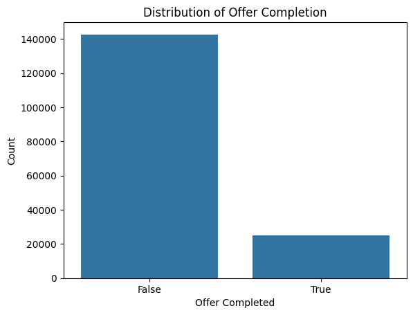

```python
#we can clearly see the imbalance nature of target variable
#which rules out accuracy and Precision to be the metrics
import seaborn as sns
import matplotlib.pyplot as plt

offer_completion_counts = data['successful_completion'].value_counts()
sns.barplot(x=offer_completion_counts.index, y=offer_completion_counts.values)
plt.title('Distribution of Offer Completion')
plt.xlabel('Offer Completed')
plt.ylabel('Count')
plt.show()
```

```python
from sklearn.metrics import accuracy_score, precision_score, recall_score, f1_score, roc_auc_score

y_pred = model.predict(X_test)

print("Accuracy:", accuracy_score(y_test, y_pred))
print("Precision:", precision_score(y_test, y_pred))
print("Recall:", recall_score(y_test, y_pred))
print("F1-Score:", f1_score(y_test, y_pred))
```

```
Accuracy: 0.9302778804475657
Precision: 0.7543038922155688
Recall: 0.8410181514708951
F1-Score: 0.7953043306698234
```

[output not shown]

## understanding the results:

`Accuracy = 93.02% :`

```
    - RandomForest is correctly classifying users which will either take or not take the offer 93.02%.
    - BUT

    - We already know that our data is imbalanced accuracy alone may be misleading.
```

`Precision =75.43%`

- our model predicts a user will complete an offer, 75.43% of the time it is correct.

`Recall = 84.10%`

- Our model successfully identifies 84.10% of actual offer completers. This means we are capturing most of the potential customers who complete offers.

`F1-Score =79.53%`

- balance between Precision and Recall.

**WE WERE TARGETING ON PRECISION + RECALL + F1-SCORE, due to imbalance in our dataset but these scores though are good, we can have a better prediction model**

```python
from xgboost import XGBClassifier

xgb_model = XGBClassifier(n_estimators=200, learning_rate=0.1, random_state=42)
xgb_model.fit(X_train, y_train)

y_pred_xgb = xgb_model.predict(X_test)

print("XGBoost Accuracy:", accuracy_score(y_test, y_pred_xgb))
print(classification_report(y_test, y_pred_xgb))
```

```
XGBoost Accuracy: 0.9428782634992103
              precision    recall  f1-score   support

       False       1.00      0.93      0.96     24968
        True       0.74      0.98      0.85      4793

    accuracy                           0.94     29761
   macro avg       0.87      0.96      0.91     29761
weighted avg       0.96      0.94      0.95     29761
```

```python
from sklearn.metrics import accuracy_score, precision_score, recall_score, f1_score, roc_auc_score


print("Accuracy:", accuracy_score(y_test, y_pred_xgb))
print("Precision:", precision_score(y_test, y_pred_xgb))
print("Recall:", recall_score(y_test, y_pred_xgb))
print("F1-Score:", f1_score(y_test, y_pred_xgb))
```

```
Accuracy: 0.9428782634992103
Precision: 0.7438120763045878
Recall: 0.9843521802628834
F1-Score: 0.8473419540229885
```

## understanding the XGB MODEL results:

`Accuracy = 94.28% :`

```
    - XGB model is correctly classifying users which will either take or not take the offer 94.28%, this is an improvement from RandomForest
    - BUT

    - again as we  know that our data is imbalanced accuracy alone may be misleading.
```

`Precision =74.38%`

- our model predicts a user will complete an offer, 74.38% of the time it is correct. This is a fraction less than our RF

`Recall = 98.44%`

- Our model successfully identifies 98.44% of actual offer completers. This means we are capturing most of the potential customers who complete offers.
- This is one of the most importatn metric for our model and this is a great imporment from our RF.

``F1-Score =84.73%`

- balance between Precision and Recall.

```python
from sklearn.linear_model import LogisticRegression

log_model = LogisticRegression(max_iter=500)
log_model.fit(X_train, y_train)

y_pred_log = log_model.predict(X_test)
print("Logistic Regression Accuracy:", accuracy_score(y_test, y_pred_log))
print(classification_report(y_test, y_pred_log))
```

```
Logistic Regression Accuracy: 0.9438526931218709
              precision    recall  f1-score   support

       False       1.00      0.93      0.97     24968
        True       0.74      1.00      0.85      4793

    accuracy                           0.94     29761
   macro avg       0.87      0.97      0.91     29761
weighted avg       0.96      0.94      0.95     29761
```

```python
from sklearn.metrics import accuracy_score, precision_score, recall_score, f1_score, roc_auc_score


print("Accuracy:", accuracy_score(y_test, y_pred_log))
print("Precision:", precision_score(y_test, y_pred_log))
print("Recall:", recall_score(y_test, y_pred_log))
print("F1-Score:", f1_score(y_test, y_pred_log))
```

```
Accuracy: 0.9438526931218709
Precision: 0.7414913366336634
Recall: 1.0
F1-Score: 0.8515590299369281
```

## understanding the LOGISTIC REGRESSION Model results:

`Accuracy = 94.38% :`

```
    - this model is correctly classifying users which will either take or not take the offer 94.38%.
    - BUT this alone does not hold much significance.
```

`Precision =74.15%`

- almost same as XBG, a fraction less than RF.

`Recall = 100%`

- Our model successfully identifies 100% of actual offer completers. This means we are capturing almost all customers who complete offers.

`F1-Score =85.16%`

- balance between Precision and Recall.

**THIS MODEL LOOKS to be the best one for PREDICITON **

## FINE-TUNING:

We had learned GridSearchCV for fine tuning our model

- let's try to shake fine tune Logistic Regression model
- Steps to remember while fine tuning :

  `STEP1:`
  - We need to import GridSearchCV module from sklearn.model_selection library, that's all

  `STEP2:`
  - which params to choose for fine-tuning? this is the most important one.
  - param_grid is one of the params that takes a dictionary with several key-values in it, we have a whole list to choose from, again to decide the best ones you need to know how the model perfromed and which part of tuning would improve the accurancy.
  - We will consider C (Inverse of regularization strength) → will heop in controling the complexity.
  - penalty → Can be Lasso or Ridge.
  - solver → Choose based on the penalty type. are pretty common ones. We can check below official link for it. https://scikit-learn.org/stable/modules/generated/sklearn.model_selection.GridSearchCV.html

  `STEP3:`
  - intialize the model with required params, and then fit to check how much it increased the accuracy, then look for which were the best hyperparameters, etimators

  `STEP4:`
  - Predict and check accuracy_score, precision_score, recall_score, f1_score

```python
#regularization is the most important aspect we will start focusing on
# strenghting the regulatziaition and then as we move ahead see what more change
#will be required

from sklearn.model_selection import GridSearchCV
from sklearn.linear_model import LogisticRegression


#Above link has complete details on regualization technique
#Regularization strenght (C) and types of regularizaiton (penalty)
#solver that supports our required techniques
param_grid = {
    'C': [0.001, 0.01, 0.1, 1, 10, 100],
    'penalty': ['l1', 'l2'],
    'solver': ['liblinear', 'saga']
}

#Step1:Intitialziton

log_reg = LogisticRegression(max_iter=1000)

#step2: Performoing GridSearchCV
grid_search = GridSearchCV(log_reg, param_grid, scoring='f1', cv=5, n_jobs=-1, verbose=2)
grid_search.fit(X_train, y_train)

#step3 Best hyperparameters
print("Best Parameters:", grid_search.best_params_)

#Step3 best evaluator
best_model = grid_search.best_estimator_
y_pred = best_model.predict(X_test)

# step4 checking our Metrics post
from sklearn.metrics import accuracy_score, precision_score, recall_score, f1_score

print("Optimized Accuracy:", accuracy_score(y_test, y_pred))
print("Optimized Precision:", precision_score(y_test, y_pred))
print("Optimized Recall:", recall_score(y_test, y_pred))
print("Optimized F1-Score:", f1_score(y_test, y_pred))
```

[output not shown]

[output not shown]

[output not shown]

[output not shown]

[output not shown]

[output not shown]

[output not shown]

[output not shown]

[output not shown]

[output not shown]

[output not shown]

[output not shown]

[output not shown]

[output not shown]

[output not shown]

[output not shown]

[output not shown]

[output not shown]

[output not shown]

[output not shown]

[output not shown]

[output not shown]

[output not shown]

[output not shown]

[output not shown]

[output not shown]

[output not shown]

[output not shown]

[output not shown]

[output not shown]

[output not shown]

[output not shown]

[output not shown]

[output not shown]

[output not shown]

[output not shown]

[output not shown]

[output not shown]

[output not shown]

[output not shown]

[output not shown]

[output not shown]

[output not shown]

[output not shown]

[output not shown]

[output not shown]

[output not shown]

[output not shown]

[output not shown]

[output not shown]

[output not shown]

[output not shown]

[output not shown]

[output not shown]

[output not shown]

[output not shown]

[output not shown]

[output not shown]

[output not shown]

[output not shown]

[output not shown]

[output not shown]

```
[CV] END .....................C=100, penalty=l2, solver=saga; total time=  17.9s
Best Parameters: {'C': 0.01, 'penalty': 'l1', 'solver': 'liblinear'}
Optimized Accuracy: 0.9438526931218709
Optimized Precision: 0.7414913366336634
Optimized Recall: 1.0
Optimized F1-Score: 0.8515590299369281
```

## We got ConvergenceWarning warning?

- meaning our model did not fully converge within the given number of iterations (max_iter=1000).
- lets' try to see what we can do?
- remember right hand thumb rule for Logistic Regression, scale the data, normalized data works the best with LR.
- Regularization might betoo strong, will increae the C value.
- try with much many iterations
- use 'solver': 'liblinear' provided by last run.

```python
#fixing the model

from sklearn.preprocessing import StandardScaler

scaler = StandardScaler()
X_train_scaled = scaler.fit_transform(X_train)
X_test_scaled = scaler.transform(X_test)

log_reg = LogisticRegression(max_iter=5000, solver='liblinear')

param_grid = {
    'C': [0.1, 1, 10, 100, 1000],
    'penalty': ['l1', 'l2'],
}

grid_search = GridSearchCV(log_reg, param_grid, scoring='f1', cv=5, n_jobs=-1, verbose=2)
grid_search.fit(X_train, y_train)
print("Best Parameters:", grid_search.best_params_)
best_model = grid_search.best_estimator_
y_pred = best_model.predict(X_test)
from sklearn.metrics import accuracy_score, precision_score, recall_score, f1_score
print("Optimized Accuracy:", accuracy_score(y_test, y_pred))
print("Optimized Precision:", precision_score(y_test, y_pred))
print("Optimized Recall:", recall_score(y_test, y_pred))
print("Optimized F1-Score:", f1_score(y_test, y_pred))
```

```
Fitting 5 folds for each of 10 candidates, totalling 50 fits
[CV] END ..................................C=0.1, penalty=l1; total time=   0.2s
[CV] END ..................................C=0.1, penalty=l1; total time=   0.2s
[CV] END ..................................C=0.1, penalty=l1; total time=   0.3s
[CV] END ..................................C=0.1, penalty=l1; total time=   0.3s
[CV] END ..................................C=0.1, penalty=l1; total time=   0.2s
[CV] END ..................................C=0.1, penalty=l2; total time=   0.3s
[CV] END ..................................C=0.1, penalty=l2; total time=   0.3s
[CV] END ..................................C=0.1, penalty=l2; total time=   0.2s
[CV] END ..................................C=0.1, penalty=l2; total time=   0.4s
[CV] END ..................................C=0.1, penalty=l2; total time=   0.3s
[CV] END ....................................C=1, penalty=l1; total time=   0.3s
[CV] END ....................................C=1, penalty=l1; total time=   0.2s
[CV] END ....................................C=1, penalty=l1; total time=   0.2s
[CV] END ....................................C=1, penalty=l1; total time=   0.3s
[CV] END ....................................C=1, penalty=l1; total time=   0.2s
[CV] END ....................................C=1, penalty=l2; total time=   0.3s
[CV] END ....................................C=1, penalty=l2; total time=   0.2s
[CV] END ....................................C=1, penalty=l2; total time=   0.4s
[CV] END ....................................C=1, penalty=l2; total time=   0.3s
[CV] END ....................................C=1, penalty=l2; total time=   0.3s
[CV] END ...................................C=10, penalty=l1; total time=   0.2s
[CV] END ...................................C=10, penalty=l1; total time=   0.4s
[CV] END ...................................C=10, penalty=l1; total time=   0.2s
[CV] END ...................................C=10, penalty=l1; total time=   0.3s
[CV] END ...................................C=10, penalty=l1; total time=   0.4s
[CV] END ...................................C=10, penalty=l2; total time=   0.2s
[CV] END ...................................C=10, penalty=l2; total time=   0.3s
[CV] END ...................................C=10, penalty=l2; total time=   0.3s
[CV] END ...................................C=10, penalty=l2; total time=   0.3s
[CV] END ...................................C=10, penalty=l2; total time=   0.3s
[CV] END ..................................C=100, penalty=l1; total time=   0.3s
[CV] END ..................................C=100, penalty=l1; total time=   0.4s
[CV] END ..................................C=100, penalty=l1; total time=   0.2s
[CV] END ..................................C=100, penalty=l1; total time=   0.3s
[CV] END ..................................C=100, penalty=l1; total time=   0.3s
[CV] END ..................................C=100, penalty=l2; total time=   0.3s
[CV] END ..................................C=100, penalty=l2; total time=   0.3s
[CV] END ..................................C=100, penalty=l2; total time=   0.2s
[CV] END ..................................C=100, penalty=l2; total time=   0.4s
[CV] END ..................................C=100, penalty=l2; total time=   0.3s
[CV] END .................................C=1000, penalty=l1; total time=   0.3s
[CV] END .................................C=1000, penalty=l1; total time=   0.2s
[CV] END .................................C=1000, penalty=l1; total time=   0.3s
[CV] END .................................C=1000, penalty=l1; total time=   0.4s
[CV] END .................................C=1000, penalty=l1; total time=   0.2s
[CV] END .................................C=1000, penalty=l2; total time=   0.3s
[CV] END .................................C=1000, penalty=l2; total time=   0.3s
[CV] END .................................C=1000, penalty=l2; total time=   0.2s
[CV] END .................................C=1000, penalty=l2; total time=   0.3s
[CV] END .................................C=1000, penalty=l2; total time=   0.3s
Best Parameters: {'C': 0.1, 'penalty': 'l1'}
Optimized Accuracy: 0.9438526931218709
Optimized Precision: 0.7414913366336634
Optimized Recall: 1.0
Optimized F1-Score: 0.8515590299369281
```

## What did we try?

- We tried to increse the model robustness with better hyperparameter tuning. So we can balance Precision & Recall to make better predictions.

## What we will focus on now?

- To have the best prediction model, with most accurate tuned hyperparameters.

```python
import pickle
with open('xgb_model.pkl', 'wb') as model_file:
    pickle.dump(xgb_model, model_file)
print("Model saved as xgb_model.pkl")
```

```
Model saved as xgb_model.pkl
```

```python
with open('xgb_model.pkl', 'rb') as model_file:
    loaded_model = pickle.load(model_file)
print("Model loaded successfully")
```

```
Model loaded successfully
```

```python
new_data = [[55, 110000, 1200, 0, 1, 0, 250, 1, 1]]
prediction = loaded_model.predict(new_data)
proba = loaded_model.predict_proba(new_data)

print(f"Predicted Class: {prediction[0]}")
print(f"Prediction Probabilities: {proba}")
```

```
Predicted Class: 0
Prediction Probabilities: [[9.999920e-01 8.002372e-06]]
```

## We realized here that the model is overfitting, as it predict the offer will be completed only when we provide the offer_completed feature =1

- The approach we had so far, is leading to overfitting, meaning, it has learned a pattern, even after trying to regularize and enhance using gridSearch the model is not good, why?
- Because it `considers the successful completion as linear with Offer completed`. There will be no entry where offer_recieved or viewed will have successful_completion as True, hence model is not knowing that offer_recieved is the starting phase which will ultimately lead to completed.
- **Now We must to do 2 things:**

  ```
   - Change the dataFrame, so the offer_received + viewed + completed pairs are clubbed together into 1, by which model based on other features will learn that offer_recieved --> completed.

   - We will stick to XGB classifier only, as we would need to do a lot of Regularization to imporve the models Metrics and can target one model.

   - Let's start with customizing our DF
  ```

```python
def preprocess_data(transcript):

    agg_data = transcript.groupby(['person', 'offer_id']).agg({
        'offer_received': 'max',
        'offer_viewed': 'max',
        'offer_completed': 'max',
        'time': ['min', 'max'],
        'reward': 'sum'
    }).reset_index()

    agg_data.columns = ['person', 'offer_id', 'offer_received', 'offer_viewed', 'offer_completed',
                        'time_received', 'time_completed', 'total_reward']

    agg_data['time_to_complete'] = agg_data['time_completed'] - agg_data['time_received']
    agg_data['time_to_complete'].fillna(-1, inplace=True)

    return agg_data


agg_transcript = preprocess_data(transcript)
```

```python
agg_transcript = agg_transcript.merge(profile, how='left', left_on='person', right_on='person')
agg_transcript = agg_transcript.merge(portfolio, how='left', left_on='offer_id', right_on='offer_id').drop(columns=['offer_id'])
```

## TOTAL OFFERS SENT

```python
agg_transcript[(agg_transcript['offer_received'] == 1)].shape
```

```
(63288, 21)
```

## TOTAL OFFERS VIEWED

```python
agg_transcript[(agg_transcript['offer_viewed'] == 1)].shape
```

```
(49135, 21)
```

## TOTAL COMPLETED OFFERS

```python
agg_transcript[(agg_transcript['offer_completed'] == 1)].shape
```

```
(28996, 21)
```

## TOTAL OFFERS WHICH WERE RECEIVED + VIEWED BUT NOT COMPLETED

```python
agg_transcript[(agg_transcript['offer_received'] == 1) & (agg_transcript['offer_viewed'] == 1) & (agg_transcript['offer_completed'] != 1) ].shape
```

```
(24675, 21)
```

## TOTAL OFFERS RECEIVED + VIEWED + COMPLETED

```python
agg_transcript[(agg_transcript['offer_received'] == 1) & (agg_transcript['offer_viewed'] == 1) & (agg_transcript['offer_completed'] == 1) ].shape
```

```
(24460, 21)
```

## TOTAL OFFERS ONLY RECEIVED

```python
agg_transcript[(agg_transcript['offer_received'] == 1) & (agg_transcript['offer_viewed'] != 1) & (agg_transcript['offer_completed'] != 1) ].shape
```

```
(9617, 21)
```

## TOTAL OFFERS RECEVIED NOT VIEWED BUT COMPLETED

```python
agg_transcript[(agg_transcript['offer_received'] == 1) & (agg_transcript['offer_viewed'] != 1) & (agg_transcript['offer_completed'] == 1) ].shape
```

```
(4536, 21)
```

```python
import pandas as pd

promo_status = pd.DataFrame([{
    'TOT_RCV': agg_transcript[agg_transcript['offer_received'] == 1].shape[0],
    'TOT_VIEW': agg_transcript[agg_transcript['offer_viewed'] == 1].shape[0],
    'TOT_COMP': agg_transcript[agg_transcript['offer_completed'] == 1].shape[0],
    'TOT_RCV_VW_NOT_COMP': agg_transcript[(agg_transcript['offer_received'] == 1) &
                                          (agg_transcript['offer_viewed'] == 1) &
                                          (agg_transcript['offer_completed'] != 1)].shape[0],
    'TOT_RCV_VW_COMP': agg_transcript[(agg_transcript['offer_received'] == 1) &
                                      (agg_transcript['offer_viewed'] == 1) &
                                      (agg_transcript['offer_completed'] == 1)].shape[0],
    'TOT_ONLY_RCV': agg_transcript[(agg_transcript['offer_received'] == 1) &
                                   (agg_transcript['offer_viewed'] != 1) &
                                   (agg_transcript['offer_completed'] != 1)].shape[0],
    'TOT_RCV_COMP_ONLY': agg_transcript[(agg_transcript['offer_received'] == 1) &
                                        (agg_transcript['offer_viewed'] != 1) &
                                        (agg_transcript['offer_completed'] == 1)].shape[0]
}])

promo_status=pd.DataFrame(promo_status.stack(), columns=['count']).reset_index().rename(columns={'index': 'offer_status'})
```

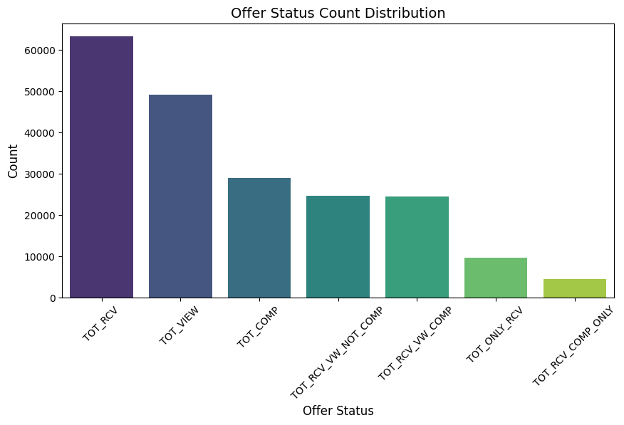

```python
plt.figure(figsize=(10, 5))
sns.barplot(x='level_1', y='count', data=promo_status, palette='viridis')

plt.xlabel('Offer Status', fontsize=12)
plt.ylabel('Count', fontsize=12)
plt.title('Offer Status Count Distribution', fontsize=14)
plt.xticks(rotation=45)

plt.show()
```

```python
feature_names = ['age', 'income', 'membership_days', 'offer_received', 'offer_viewed',
                  'time_to_complete', 'offer_type_bogo', 'offer_type_discount']
X = agg_transcript[feature_names]
y = agg_transcript['offer_completed']
```

```python
X_train, X_test, y_train, y_test = train_test_split(X, y, test_size=0.2, random_state=42)

xgb_model = xgb.XGBClassifier(n_estimators=100, learning_rate=0.05, max_depth=6, random_state=42)
xgb_model.fit(X_train, y_train)


y_pred_xgb = xgb_model.predict(X_test)
print("Logistic Regression Accuracy:", accuracy_score(y_test, y_pred_xgb))
print(classification_report(y_test, y_pred_xgb))


from sklearn.metrics import accuracy_score, precision_score, recall_score, f1_score, roc_auc_score




print("Accuracy:", accuracy_score(y_test, y_pred_xgb))
print("Precision:", precision_score(y_test, y_pred_xgb))
print("Recall:", recall_score(y_test, y_pred_xgb))
print("F1-Score:", f1_score(y_test, y_pred_xgb))
```

```
Logistic Regression Accuracy: 0.8691736451256122
              precision    recall  f1-score   support

           0       0.90      0.85      0.88      6844
           1       0.83      0.89      0.86      5814

    accuracy                           0.87     12658
   macro avg       0.87      0.87      0.87     12658
weighted avg       0.87      0.87      0.87     12658

Accuracy: 0.8691736451256122
Precision: 0.833922261484099
Recall: 0.8930168558651531
F1-Score: 0.8624584717607974
```

```python
with open('xgb_model_fixed.pkl', 'wb') as model_file:
    pickle.dump(xgb_model, model_file)

with open('xgb_model_fixed.pkl', 'rb') as model_file:
    loaded_model = pickle.load(model_file)
print("Model loaded successfully")
```

```
Model loaded successfully
```

```python
#'age', 'income', 'membership_days', 'offer_received', 'offer_viewed',
#         'time_to_complete', 'offer_type_bogo', 'offer_type_discount'
new_data = [[55, 110000, 1200, 1, 1, 0, 0, 1]]
prediction = loaded_model.predict(new_data)
proba = loaded_model.predict_proba(new_data)



print(f"Predicted Class: {prediction[0]}")
print(f"Prediction Probabilities: {proba}")
```

```
Predicted Class: 1
Prediction Probabilities: [[0.21478361 0.7852164 ]]
```

## This MODEL is stil a overfitting, why?

- Still considers when offer_viewed is 1 but for recieved it gives rarely 1, meaning it still considers that offer_viewed is the most impotatn feautre for prediction.
- we need to increase the Recall value & Precission by Hyperparameter Optimization → will tyr to tune most important and common HP n_estimators, max_depth, learning_rate

```python
from sklearn.model_selection import GridSearchCV

param_grid = {
    'n_estimators': [100, 200, 300],
    'learning_rate': [0.01, 0.1, 0.2],
    'max_depth': [3, 5, 7]
}

grid_search = GridSearchCV(XGBClassifier(random_state=42), param_grid, cv=3, scoring='accuracy', n_jobs=-1, verbose=2)
grid_search.fit(X_train, y_train)

print("Best Parameters:", grid_search.best_params_)
print("Best Accuracy:", grid_search.best_score_)
```

[output not shown]

[output cut: 29 more lines]

```
[CV] END ...learning_rate=0.2, max_depth=5, n_estimators=200; total time=   0.5s
[CV] END ...learning_rate=0.2, max_depth=5, n_estimators=300; total time=   0.8s
[CV] END ...learning_rate=0.2, max_depth=5, n_estimators=300; total time=   0.8s
[CV] END ...learning_rate=0.2, max_depth=5, n_estimators=300; total time=   0.7s
[CV] END ...learning_rate=0.2, max_depth=7, n_estimators=100; total time=   0.4s
[CV] END ...learning_rate=0.2, max_depth=7, n_estimators=100; total time=   0.4s
[CV] END ...learning_rate=0.2, max_depth=7, n_estimators=100; total time=   0.4s
[CV] END ...learning_rate=0.2, max_depth=7, n_estimators=200; total time=   0.7s
[CV] END ...learning_rate=0.2, max_depth=7, n_estimators=200; total time=   0.7s
[CV] END ...learning_rate=0.2, max_depth=7, n_estimators=200; total time=   0.7s
[CV] END ...learning_rate=0.2, max_depth=7, n_estimators=300; total time=   1.0s
[CV] END ...learning_rate=0.2, max_depth=7, n_estimators=300; total time=   1.0s
[CV] END ...learning_rate=0.2, max_depth=7, n_estimators=300; total time=   1.0s
Best Parameters: {'learning_rate': 0.1, 'max_depth': 5, 'n_estimators': 300}
Best Accuracy: 0.8694450296560557
```

## DON'T SEE MUCH IMPROVEMENT:

- it is still over-fitting, how? Shows our prediction works fine when we provide offer_viewed = 1 but rarely shows preictionr=1 when offer_received is provided as 1.
- this is mostly because our dataset isn't big enough now, why do i say so?
- Because now agg_data has merged rows, which is ~63k rows with combination of:
  - offer_recieved
  - offer_received + offer_viewed
  - offer_received + offer_viewed + offer_completed
  - offer_received + offer_completed
- We would focus on REGULARIZATION~~

## REGULARIZATION - Controlling Overfitting

- Regularization is a technique used in machine learning to prevent overfitting by penalizing complex models. It helps ensure that the model generalizes well to unseen data rather than just memorizing the training data.
  - Currently our model is memorizing the true patterns but also the noise in the training data. This is making our model perform well on training data but poorly on unseen data.
  - Regularization adds a penalty term to the model's loss function, forcing it to learn simpler patterns.
  - 2major Regularization that we had for Logistic Regression:
    - L1 Regularization (Lasso Regression - L1 Penalty)
    - L2 Regularization (Ridge Regression - L2 Penalty)
  - In XGBoost, we have:
    - L1 Regularization (reg_alpha) → Helps with feature selection.
    - L2 Regularization (reg_lambda) → Helps reduce overfitting without removing features.
- On top of the L1 & L2, we have utilized below to have the best ever model we can get:
  - min_child_weight
  - gamma
  - subsample
  - colsample_bytree
  - scale_pos_weight

```python
param_grid = {
    'n_estimators': [100, 200, 300],
    'learning_rate': [0.01, 0.1, 0.2],
    'max_depth': [3, 5, 7],
    'min_child_weight': [1, 3, 5],
    'gamma': [0, 0.1, 0.3, 0.5],
    'subsample': [0.5, 0.7, 1.0],
    'colsample_bytree': [0.3, 0.6, 0.8, 1.0],
    'reg_alpha': [0, 0.1, 0.5, 1.0],
    'reg_lambda': [0.5, 1.0, 1.5, 2.0],
    'scale_pos_weight': [1, 2, 5, 10]
}


grid_search = GridSearchCV(XGBClassifier(random_state=42), param_grid, cv=5, scoring='accuracy', n_jobs=-1, verbose=2)
grid_search.fit(X_train, y_train)

print("Best Parameters:", grid_search.best_params_)
print("Best Accuracy:", grid_search.best_score_)
```

[output not shown]

[output cut: 15 more lines]

[output not shown]

[output cut: 15 more lines]

[output not shown]

[output cut: 15 more lines]

[output not shown]

[output cut: 15 more lines]

[output not shown]

[output cut: 15 more lines]

[output not shown]

[output cut: 14 more lines]

[output not shown]

[output cut: 14 more lines]

[output not shown]

[output cut: 14 more lines]

[output not shown]

[output cut: 14 more lines]

[output not shown]

[output cut: 14 more lines]

[output not shown]

[output cut: 14 more lines]

[output not shown]

[output cut: 14 more lines]

[output not shown]

[output cut: 14 more lines]

[output not shown]

[output cut: 14 more lines]

[output not shown]

[output cut: 14 more lines]

[output not shown]

[output cut: 14 more lines]

[output not shown]

[output cut: 14 more lines]

[output not shown]

[output cut: 14 more lines]

[output not shown]

[output cut: 14 more lines]

[output not shown]

[output cut: 14 more lines]

[output not shown]

[output cut: 14 more lines]

[output not shown]

[output cut: 14 more lines]

[output not shown]

[output cut: 14 more lines]

[output not shown]

[output cut: 15 more lines]

[output not shown]

[output cut: 15 more lines]

[output not shown]

[output cut: 15 more lines]

[output not shown]

[output cut: 15 more lines]